# Homework 05

11/14/2021

### Tanubrata Dey (td2201)

## Part 1: distance and correlation

Load the dataset `state`, and we will use the matrix `state.x77` to answer the following questions.

```r
state = state.x77 #state dataset
head(state)
```

```
##            Population Income Illiteracy Life Exp Murder HS Grad Frost   Area
## Alabama          3615   3624        2.1    69.05   15.1    41.3    20  50708
## Alaska            365   6315        1.5    69.31   11.3    66.7   152 566432
## Arizona          2212   4530        1.8    70.55    7.8    58.1    15 113417
## Arkansas         2110   3378        1.9    70.66   10.1    39.9    65  51945
## California      21198   5114        1.1    71.71   10.3    62.6    20 156361
## Colorado         2541   4884        0.7    72.06    6.8    63.9   166 103766
```

### Question 1.a Distance: Calculate the Euclidean distance between every two state. Based on the Euclidean distance, which two states are the closest (most similar)? (2 points)

```r
state_euclidean = dist(state, method = "euclidean") #euclidean distance matrix
#state_euclidean = as.data.frame(state_euclidean)
```

```r
state_euclidean_df <- as.data.frame(as.matrix(state_euclidean)) #converting the distance matrix as a dataframe

#min(state_euclidean_df)
#write.csv(state_euclidean_df, file = "state_ed.csv")
```

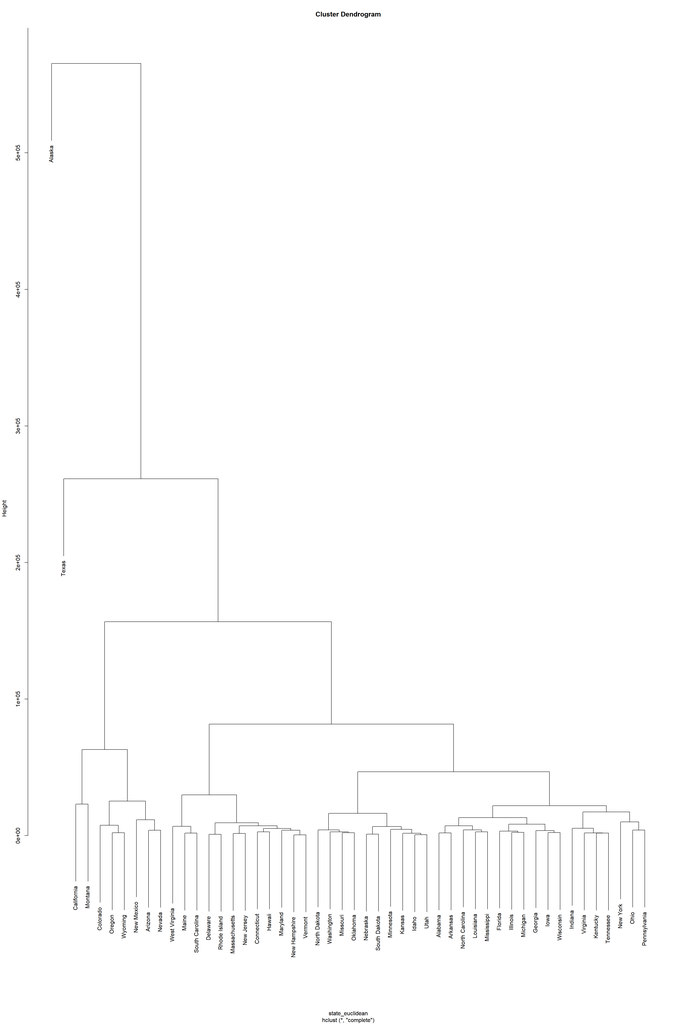

```r
plot(hclust(state_euclidean)) #plotting hierarchial clustering for distance matrix
```

```r
library(tidyverse)
library(reshape2)
x = as.matrix(state_euclidean) %>% melt(varnames = c("State_1", "State_2"), value.name = "distance") %>% arrange(distance) %>% filter(distance != 0) %>% filter(row_number()==1) #getting the states with lowest distance value

print(x)
```

```
##   State_1       State_2 distance
## 1 Vermont New Hampshire 559.5688
```

It is hard to get the minimum distance from a big distance matrix, because min() function would not work since diagonal gives 0 for distance between same states, So to verify, I first plot a hierarchial cluster of the states using distance matrix and visually it looks New Hampshire and Vermont to be the closest based on distance. To verify I checked the distance matrix using some tidyverse commands to filter the lowest ditance matrix and I get for **New Hampshire and Vermont** and it gives **559.5688** which is pretty low. To crosscheck I make the distance matrix as an R dataframe and started to look for the lowest value by each column and Vermont and New Hampshire gave the lowest overall, so based on the Euclidean distance, **New Hampshire and Vermont** are the closest.

### Question 1.b Correlation: Calculate the correlation between every two variables. Show the correlation matrix. (1 points)

```r
as.data.frame(cor(state, method = "pearson")) #correlation between every two variables of the state dataset
```

```
##             Population     Income  Illiteracy    Life Exp     Murder
## Population  1.00000000  0.2082276  0.10762237 -0.06805195  0.3436428
## Income      0.20822756  1.0000000 -0.43707519  0.34025534 -0.2300776
## Illiteracy  0.10762237 -0.4370752  1.00000000 -0.58847793  0.7029752
## Life Exp   -0.06805195  0.3402553 -0.58847793  1.00000000 -0.7808458
## Murder      0.34364275 -0.2300776  0.70297520 -0.78084575  1.0000000
## HS Grad    -0.09848975  0.6199323 -0.65718861  0.58221620 -0.4879710
## Frost      -0.33215245  0.2262822 -0.67194697  0.26206801 -0.5388834
## Area        0.02254384  0.3633154  0.07726113 -0.10733194  0.2283902
##                HS Grad      Frost        Area
## Population -0.09848975 -0.3321525  0.02254384
## Income      0.61993232  0.2262822  0.36331544
## Illiteracy -0.65718861 -0.6719470  0.07726113
## Life Exp    0.58221620  0.2620680 -0.10733194
## Murder     -0.48797102 -0.5388834  0.22839021
## HS Grad     1.00000000  0.3667797  0.33354187
## Frost       0.36677970  1.0000000  0.05922910
## Area        0.33354187  0.0592291  1.00000000
```

### Question 1.c: Interpretation for the correlation matrix. Talk about whether the variables are positive or negative correlated, the correlation is strong or weak. (1 points)

From the above correlation matrix of the variables, for Murder and Population, there is weak positive correlation because the value is 0.343. For Murder and Income, there is weak negative correlation because the value is -0.230.For Murder and Illiteracy, there is strong positive correlation because the value is 0.702. For Murder and Life expectancy, there is strong negative correlation because the value is -0.780.For Murder and HS Graduate, there is moderate negative correlation because the value is -0.487. For Murder and Frost, there is moderate negative correlation because the value is -0.538. For Murder and Area, there is weak positive correlation because the value is 0.228.

## Part2: Tidyverse: Use the dataset `GSE124548.raw.fixed.txt` to answer the following questions

### Question 2.a: Create a tibble named `HC` with gene id and all columns that have “HC” in their name

```r
library(readr)
GSE124548 <- read_delim("GSE124548.raw.fixed.txt",
     delim = "\t", escape_double = FALSE,
     trim_ws = TRUE) #loading the dataset
library(tidyverse)
```

```r
HC = GSE124548 %>% select(ID, contains("HC")) #filtering gene id and all columns that have "HC" in their name
head(HC) #printing few rows of HC
```

```
## # A tibble: 6 x 21
##   ID       Raw_10_HC_Auto_0~ Raw_13_HC_Auto_0~ Raw_16_HC_Auto_~ Raw_19_HC_Auto_~
##   <chr>                <dbl>             <dbl>            <dbl>            <dbl>
## 1 A1BG                    81                46              125              104
## 2 A1BG-AS1                49                26               80               56
## 3 A2M-AS1                 74                47              105              202
## 4 AAAS                   161                92              243              149
## 5 AACS                   199               117              218              152
## 6 AAED1                  185               210              241              254
## # ... with 16 more variables: Raw_21_HC_Immune_004 <dbl>,
## #   Raw_23_HC_Auto_076_247 <dbl>, Raw_26_HC_Auto_078_249 <dbl>,
## #   Raw_29_HC_Auto_080_251 <dbl>, Raw_3_HC_Auto_062_233 <dbl>,
## #   Raw_42_HC_Auto_089_261 <dbl>, Raw_4_HC_Immune_002 <dbl>,
## #   Raw_7_HC_Auto_064_235 <dbl>, Raw_HC_Auto_082_253 <dbl>,
## #   Raw_HC_Auto_084_255 <dbl>, Raw_HC_Auto_088_259 <dbl>,
## #   Raw_HC_Auto_091_263 <dbl>, Raw_HC_Auto_093_265 <dbl>, ...
```

```r
is_tibble(HC) #verify if its tibble
```

```
## [1] TRUE
```

### Question 2.b: Create a tibble named `CF` with gene id and all columns that have “Base” in their name

```r
CF = GSE124548 %>% select(ID, contains("Base")) #gene id and all columns that have "Base" in their name
head(CF) #printing few rows of CF
```

```
## # A tibble: 6 x 21
##   ID       Raw_11_Orkambi_0~ Raw_14_Orkambi_0~ Raw_17_Orkambi_~ Raw_1_Orkambi_0~
##   <chr>                <dbl>             <dbl>            <dbl>            <dbl>
## 1 A1BG                    38                64              140               79
## 2 A1BG-AS1                31                38               76               38
## 3 A2M-AS1                108                41               45               15
## 4 AAAS                    86               116              136               78
## 5 AACS                   128               162              243              128
## 6 AAED1                  112               190              285              118
## # ... with 16 more variables: Raw_20_Orkambi_010_Base <dbl>,
## #   Raw_24_Orkambi_012_Base <dbl>, Raw_27_Orkambi_013_Base <dbl>,
## #   Raw_30_Orkambi_014_Base <dbl>, Raw_5_Orkambi_002_Base <dbl>,
## #   Raw_8_Orkambi_004_Base <dbl>, Raw_Orkambi_015_Base <dbl>,
## #   Raw_Orkambi_016_Base <dbl>, Raw_Orkambi_017_Base <dbl>,
## #   Raw_Orkambi_018_Base <dbl>, Raw_Orkambi_020_Base <dbl>,
## #   Raw_Orkambi_021_Base <dbl>, Raw_Orkambi_022_Base <dbl>, ...
```

```r
is_tibble(CF) #verify if its tibble
```

```
## [1] TRUE
```

### Question 2.c: Use tidyverse to calculate the column sums of `CF`. Hint: use `pivot_longer`, `group_by` and `summarise` function. (1 points)

```r
CF_sum = CF %>% pivot_longer(-1, names_to = "samples", values_to = "counts") %>% group_by(samples) %>% summarise(sum(counts)) #calculating the column sums of `CF`

colnames(CF_sum) = c("Samples", "Col_counts") #changing column names
head(CF_sum) #first few lines of the df
```

```
## # A tibble: 6 x 2
##   Samples                 Col_counts
##   <chr>                        <dbl>
## 1 Raw_1_Orkambi_001_Base    21633001
## 2 Raw_11_Orkambi_006_Base   17721824
## 3 Raw_14_Orkambi_007_Base   24374342
## 4 Raw_17_Orkambi_009_Base   40756756
## 5 Raw_20_Orkambi_010_Base   29394561
## 6 Raw_24_Orkambi_012_Base   25507551
```

### Question 2.d: Use ggplot2 to create two barplot showing the column sums of all `HC` and all `CF` (2 points)

```r
HC_sum = HC %>% pivot_longer(-1, names_to = "samples", values_to = "counts") %>% group_by(samples) %>% summarise(sum(counts)) #calculating the column sums of `HC`

colnames(HC_sum) = c("Samples", "Col_counts") #changing column names
head(HC_sum) #first few lines of the df
```

```
## # A tibble: 6 x 2
##   Samples                Col_counts
##   <chr>                       <dbl>
## 1 Raw_10_HC_Auto_066_237   22149519
## 2 Raw_13_HC_Auto_068_239   18578586
## 3 Raw_16_HC_Auto_072_243   30715099
## 4 Raw_19_HC_Auto_074_245   21943263
## 5 Raw_21_HC_Immune_004     30180140
## 6 Raw_23_HC_Auto_076_247   31635754
```

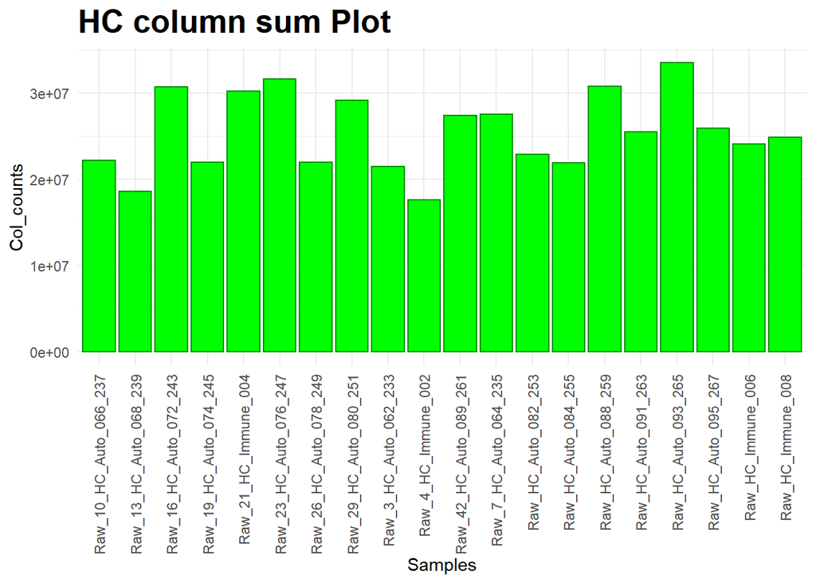

```r
library(ggplot2)
library(extrafont)
ggplot() + geom_bar(HC_sum,mapping = aes(x=Samples, y=Col_counts), stat = "identity", color="green4", fill="green1") + theme_minimal() + scale_x_discrete(guide = guide_axis(angle = 90)) + theme_minimal() +
  ggtitle("HC column sum Plot") + theme(plot.title = element_text(size=20, face="bold", vjust=1, lineheight=0.6))
```

```r
#ggplot for HC column sum
```

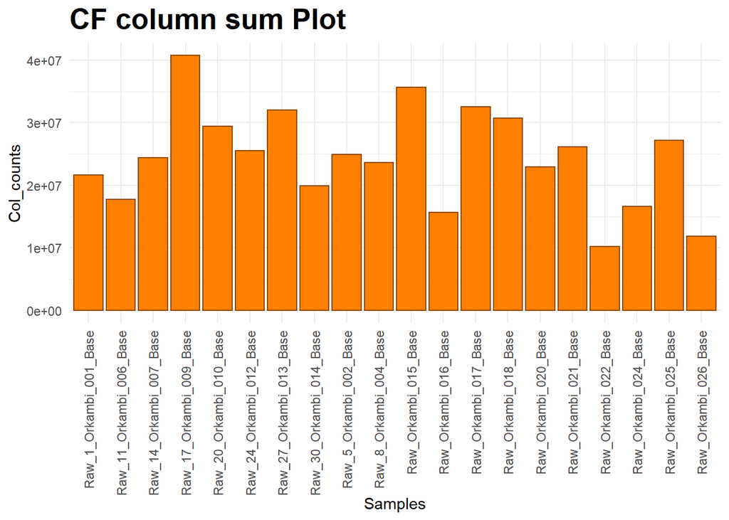

```r
ggplot() + geom_bar(CF_sum, mapping = aes(x=Samples, y=Col_counts), stat = "identity", color="darkorange4", fill="darkorange1") + scale_x_discrete(guide = guide_axis(angle = 90)) + theme_minimal() +
  ggtitle("CF column sum Plot") + theme(plot.title = element_text(size=20, face="bold", vjust=1, lineheight=0.6))
```

```r
#ggplot for CF column sum
```

### Question 2.e: Use tidyverse to calculate the average count for genes in `HC` and `CF`. Hint: use `pivot_longer`, `group_by` and `summarise` function. (2 points)

```r
HC_average = HC %>% pivot_longer(-1, names_to = "samples", values_to = "counts") %>% group_by(ID) %>% summarise(mean(counts)) #calculating the average count for genes in `HC`

colnames(HC_average) = c("Gene_ID", "Avg_gene_counts") #changing column names
head(HC_average) #first few lines of HC average gene counts
```

```
## # A tibble: 6 x 2
##   Gene_ID  Avg_gene_counts
##   <chr>              <dbl>
## 1 A1BG                92.4
## 2 A1BG-AS1            57.7
## 3 A2M-AS1             92.4
## 4 AAAS               150.
## 5 AACS               177.
## 6 AAED1              235.
```

```r
CF_average = CF %>% pivot_longer(!ID, names_to = "samples", values_to = "counts") %>% group_by(ID) %>% summarise(mean(counts)) #calculating the average count for genes in `CF`

colnames(CF_average) = c("Gene_ID", "Avg_gene_counts") #changing column names
head(CF_average) #first few lines of HC average gene counts
```

```
## # A tibble: 6 x 2
##   Gene_ID  Avg_gene_counts
##   <chr>              <dbl>
## 1 A1BG                77.2
## 2 A1BG-AS1            46.6
## 3 A2M-AS1             92.4
## 4 AAAS               111.
## 5 AACS               166.
## 6 AAED1              182.
```

### Question 2.f: Use tidyverse to sort the average count for genes in `HC` and `CF` from highest to lowest (1 points)

```r
HC_average_sorted = HC_average %>% arrange(desc(Avg_gene_counts)) #sorting the average count for genes in `HC`
head(HC_average_sorted) #first few lines of the sorted average counts
```

```
## # A tibble: 6 x 2
##   Gene_ID Avg_gene_counts
##   <chr>             <dbl>
## 1 RN7SK           831558.
## 2 EEF1A1          248255.
## 3 S100A9          173981.
## 4 UBB             159612.
## 5 MALAT1          149325.
## 6 RMRP            145384.
```

```r
CF_average_sorted = CF_average %>% arrange(desc(Avg_gene_counts)) #sorting the average count for genes in `CF`
head(CF_average_sorted) #first few lines of the sorted average counts
```

```
## # A tibble: 6 x 2
##   Gene_ID Avg_gene_counts
##   <chr>             <dbl>
## 1 RN7SK           785272.
## 2 S100A9          338964.
## 3 EEF1A1          194020.
## 4 NAMPT           149094.
## 5 FTL             132493.
## 6 S100A8          132279.
```